# Text Analysis

Import the required libraries.

```python
import nltk
from nltk.corpus import gutenberg
from pprint import pprint
nltk.download('gutenberg')
nltk.download('punkt')
```

```
True
```

Check the sample text files available from project gutenberg.

```python
nltk.corpus.gutenberg.fileids()
```

```
['austen-emma.txt',
 'austen-persuasion.txt',
 'austen-sense.txt',
 'bible-kjv.txt',
 'blake-poems.txt',
 'bryant-stories.txt',
 'burgess-busterbrown.txt',
 'carroll-alice.txt',
 'chesterton-ball.txt',
 'chesterton-brown.txt',
 'chesterton-thursday.txt',
 'edgeworth-parents.txt',
 'melville-moby_dick.txt',
 'milton-paradise.txt',
 'shakespeare-caesar.txt',
 'shakespeare-hamlet.txt',
 'shakespeare-macbeth.txt',
 'whitman-leaves.txt']
```

Extract the text in the book, "Alice's Adventures in Wonderland"

```python
alice = gutenberg.raw(fileids='carroll-alice.txt')
sample_text = """Though the exact definition varies, natural language can broadly be defined in contrast to artificial or constructed languages.
                Such artificial languages include computer programming languages and international auxiliary languages. We also separate natural language
                from other communication systems in nature. Examples of such communication systems include animal dances and songs,
                to which some linguistic analogies apply"""
```

Check the number of characters in the book-

```python
len(alice)
```

```
144395
```

Choose a small slice (100 characters) to see the text-

```python
alice[0:100]
```

```
"[Alice's Adventures in Wonderland by Lewis Carroll 1865]\n\nCHAPTER I. Down the Rabbit-Hole\n\nAlice was"
```

Extract the sentences in the texts by using the sentence tokenizers available in nltk-

```python
default_st = nltk.sent_tokenize
sample_sentences = default_st(text=sample_text)
alice_sentences = default_st(text=alice)
```

```python
print('Total sentences in sample_text:', len(sample_sentences))
print('Sample text sentences :-')
pprint(sample_sentences)
```

```
Total sentences in sample_text: 4
Sample text sentences :-
['Though the exact definition varies, natural language can broadly be defined '
 'in contrast to artificial or constructed languages.',
 'Such artificial languages include computer programming languages and '
 'international auxiliary languages.',
 'We also separate natural language\n'
 '                from other communication systems in nature.',
 'Examples of such communication systems include animal dances and songs, \n'
 '                to which some linguistic analogies apply']
```

```python
print('\nTotal sentences in alice:', len(alice_sentences))
print('First 5 sentences in alice:-')
pprint(alice_sentences[0:5])
```

```
Total sentences in alice: 1625
First 5 sentences in alice:-
["[Alice's Adventures in Wonderland by Lewis Carroll 1865]\n\nCHAPTER I.",
 'Down the Rabbit-Hole\n'
 '\n'
 'Alice was beginning to get very tired of sitting by her sister on the\n'
 'bank, and of having nothing to do: once or twice she had peeped into the\n'
 'book her sister was reading, but it had no pictures or conversations in\n'
 "it, 'and what is the use of a book,' thought Alice 'without pictures or\n"
 "conversation?'",
 'So she was considering in her own mind (as well as she could, for the\n'
 'hot day made her feel very sleepy and stupid), whether the pleasure\n'
 'of making a daisy-chain would be worth the trouble of getting up and\n'
 'picking the daisies, when suddenly a White Rabbit with pink eyes ran\n'
 'close by her.',
 'There was nothing so VERY remarkable in that; nor did Alice think it so\n'
 "VERY much out of the way to hear the Rabbit say to itself, 'Oh dear!",
 'Oh dear!']
```

```python
punkt_st = nltk.tokenize.PunktSentenceTokenizer()
sample_sentences = punkt_st.tokenize(sample_text)
pprint(sample_sentences)
```

```
['Though the exact definition varies, natural language can broadly be defined '
 'in contrast to artificial or constructed languages.',
 'Such artificial languages include computer programming languages and '
 'international auxiliary languages.',
 'We also separate natural language\n'
 '                from other communication systems in nature.',
 'Examples of such communication systems include animal dances and songs, \n'
 '                to which some linguistic analogies apply']
```

Use a word tokenizer to extract the words in a text corpus-

```python
default_wt = nltk.word_tokenize
words = default_wt(sample_text)
print(words)
```

```
['Though', 'the', 'exact', 'definition', 'varies', ',', 'natural', 'language', 'can', 'broadly', 'be', 'defined', 'in', 'contrast', 'to', 'artificial', 'or', 'constructed', 'languages', '.', 'Such', 'artificial', 'languages', 'include', 'computer', 'programming', 'languages', 'and', 'international',…
```

```python
treebank_wt = nltk.TreebankWordTokenizer()
words_trb = treebank_wt.tokenize(sample_text)
print(words_trb)
```

```
['Though', 'the', 'exact', 'definition', 'varies', ',', 'natural', 'language', 'can', 'broadly', 'be', 'defined', 'in', 'contrast', 'to', 'artificial', 'or', 'constructed', 'languages.', 'Such', 'artificial', 'languages', 'include', 'computer', 'programming', 'languages', 'and', 'international', 'au…
```

# Task 1. Tokenize a paragraph in another language into sentences.

I took 2000 characters from the alice text variable and converted it to spanish using google translate for the task below.

```python
alice_spanish="""


[Las aventuras de Alicia en el país de las maravillas de Lewis Carroll 1865] \ n \ nCAPÍTULO I. Por la madriguera del conejo \ n \ nAlice estaba empezando a cansarse de sentarse junto a su hermana en el \ nbanco y de no tener nada que hacer: una vez o dos veces se había asomado al \ nlibro que estaba leyendo su hermana, pero no tenía imágenes ni conversaciones \ n, '¿y de qué sirve un libro', pensó Alice 'sin imágenes o \ nconversación?' \ n \ nEntonces ella estaba considerando en su propia mente (lo mejor que podía, porque el día caluroso la hacía sentir muy somnolienta y estúpida), si el placer \ n de hacer una cadena de margaritas valdría la pena de levantarse y \ ncoger el margaritas, cuando de repente un Conejo Blanco con ojos rosados corrió \ ncerca de ella. \ n \ nNo había nada MUY notable en eso; ni Alicia lo pensó tan \ nMuy fuera de lugar escuchar al Conejo decirse a sí mismo: ' ¡Oh, Dios mío! ¡Oh, Dios mío! ¡Llegaré tarde! (cuando lo pensó más tarde, no se le ocurrió que debería haberse maravillado de esto, pero en ese momento todo parecía bastante natural); pero cuando el Conejo realmente TOMÓ UN RELOJ DE SU CHALECO-BOLSILLO, y lo miró, y luego se apresuró, \ nAlice se puso de pie, porque pasó por su mente que nunca antes había visto un conejo con un bolsillo en el chaleco o un reloj para sacar de él, y ardiendo de curiosidad, corrió por el campo \ na detrás de él, y afortunadamente llegó justo a tiempo para verlo saltar por un gran \ nhoy de conejo debajo del seto. \ n \ nEn otro momento, Alice fue detrás de él, sin considerar ni una sola vez cómo \ nen el mundo tenía que salir de nuevo. \ n \ nLa madriguera del conejo seguía recto como un túnel por algún camino, y luego \ nse hundió repentinamente, tan repentinamente que Alice no tuvo ni un momento para pensar \ na en detenerse antes se encontró cayendo en un \ npozo muy profundo. \ n \ nO el pozo era muy profundo, o cayó muy lentamente, porque tenía \ nmucho tiempo mientras bajaba para mirar a su alrededor y preguntarse qué iba a pasar a continuación. Primero, trató de mirar hacia abajo y distinguir a qué \ nse dirigía, pero era demasiado oscuro



"""

alice_spanish_sent=default_st(text=alice_spanish)
```

Check the sentences extracted by the tokenizer-

```python
alice_spanish_sent
```

```
["\n\n\n[Las aventuras de Alicia en el país de las maravillas de Lewis Carroll 1865] \\ n \\ nCAPÍTULO I. Por la madriguera del conejo \\ n \\ nAlice estaba empezando a cansarse de sentarse junto a su hermana en el \\ nbanco y de no tener nada que hacer: una vez o dos veces se había asomado al \\ nl…
 '\\ n \\ nEntonces ella estaba considerando en su propia mente (lo mejor que podía, porque el día caluroso la hacía sentir muy somnolienta y estúpida), si el placer \\ n de hacer una cadena de margaritas valdría la pena de levantarse y \\ ncoger el margaritas, cuando de repente un Conejo Blanco con…
 "\\ n \\ nNo había nada MUY notable en eso; ni Alicia lo pensó tan \\ nMuy fuera de lugar escuchar al Conejo decirse a sí mismo: ' ¡Oh, Dios mío!",
 '¡Oh, Dios mío!',
 '¡Llegaré tarde!',
 '(cuando lo pensó más tarde, no se le ocurrió que debería haberse maravillado de esto, pero en ese momento todo parecía bastante natural); pero cuando el Conejo realmente TOMÓ UN RELOJ DE SU CHALECO-BOLSILLO, y lo miró, y luego se apresuró, \\ nAlice se puso de pie, porque pasó por su mente que nun…
 '\\ n \\ nEn otro momento, Alice fue detrás de él, sin considerar ni una sola vez cómo \\ nen el mundo tenía que salir de nuevo.',
 '\\ n \\ nLa madriguera del conejo seguía recto como un túnel por algún camino, y luego \\ nse hundió repentinamente, tan repentinamente que Alice no tuvo ni un momento para pensar \\ na en detenerse antes se encontró cayendo en un \\ npozo muy profundo.',
 '\\ n \\ nO el pozo era muy profundo, o cayó muy lentamente, porque tenía \\ nmucho tiempo mientras bajaba para mirar a su alrededor y preguntarse qué iba a pasar a continuación.',
 'Primero, trató de mirar hacia abajo y distinguir a qué \\ nse dirigía, pero era demasiado oscuro']
```

```python
len(alice_spanish_sent)
```

```
10
```

Check the output of the Punkt sentence tokenizer.

```python
punkt_st.tokenize(alice_spanish)
```

```
["\n\n\n[Las aventuras de Alicia en el país de las maravillas de Lewis Carroll 1865] \\ n \\ nCAPÍTULO I. Por la madriguera del conejo \\ n \\ nAlice estaba empezando a cansarse de sentarse junto a su hermana en el \\ nbanco y de no tener nada que hacer: una vez o dos veces se había asomado al \\ nl…
 '\\ n \\ nEntonces ella estaba considerando en su propia mente (lo mejor que podía, porque el día caluroso la hacía sentir muy somnolienta y estúpida), si el placer \\ n de hacer una cadena de margaritas valdría la pena de levantarse y \\ ncoger el margaritas, cuando de repente un Conejo Blanco con…
 "\\ n \\ nNo había nada MUY notable en eso; ni Alicia lo pensó tan \\ nMuy fuera de lugar escuchar al Conejo decirse a sí mismo: ' ¡Oh, Dios mío!",
 '¡Oh, Dios mío!',
 '¡Llegaré tarde!',
 '(cuando lo pensó más tarde, no se le ocurrió que debería haberse maravillado de esto, pero en ese momento todo parecía bastante natural); pero cuando el Conejo realmente TOMÓ UN RELOJ DE SU CHALECO-BOLSILLO, y lo miró, y luego se apresuró, \\ nAlice se puso de pie, porque pasó por su mente que nun…
 '\\ n \\ nEn otro momento, Alice fue detrás de él, sin considerar ni una sola vez cómo \\ nen el mundo tenía que salir de nuevo.',
 '\\ n \\ nLa madriguera del conejo seguía recto como un túnel por algún camino, y luego \\ nse hundió repentinamente, tan repentinamente que Alice no tuvo ni un momento para pensar \\ na en detenerse antes se encontró cayendo en un \\ npozo muy profundo.',
 '\\ n \\ nO el pozo era muy profundo, o cayó muy lentamente, porque tenía \\ nmucho tiempo mientras bajaba para mirar a su alrededor y preguntarse qué iba a pasar a continuación.',
 'Primero, trató de mirar hacia abajo y distinguir a qué \\ nse dirigía, pero era demasiado oscuro']
```

```python
len(punkt_st.tokenize(alice_spanish))
```

```
10
```

As we can see, the outputs from both the tokenizers is the same.

# Stemming

```python
from nltk.stem import PorterStemmer
ps = PorterStemmer()
```

```python
print(ps.stem('lying'))
```

```
lie
```

# Task 2: Use Snowball Stemmer to identify stems of 10 words in a language other than English.

Use a word tokenizer to extract the words in the text.

```python
esp_words = treebank_wt.tokenize(alice_spanish)
print(esp_words)
```

```
['[', 'Las', 'aventuras', 'de', 'Alicia', 'en', 'el', 'país', 'de', 'las', 'maravillas', 'de', 'Lewis', 'Carroll', '1865', ']', '\\', 'n', '\\', 'nCAPÍTULO', 'I.', 'Por', 'la', 'madriguera', 'del', 'conejo', '\\', 'n', '\\', 'nAlice', 'estaba', 'empezando', 'a', 'cansarse', 'de', 'sentarse', 'junto'…
```

Use a stemmer to extract the roots of a list of words.

```python
words=['CAPÍTULO', 'Por', 'podía', 'madriguera', 'del', 'conejo', 'Alice',
       'estaba', 'empezando', 'caluroso', 'cansarse', 'mucho', 'considerando', 'sentarse', 'junto']

from nltk.stem import SnowballStemmer

snb_stemmer=SnowballStemmer(language='spanish')

for word in words:
    print(snb_stemmer.stem(word))
```

```
capitul
por
pod
madriguer
del
conej
alic
estab
empez
calur
cans
much
consider
sent
junt
```

The above piece of code works as expected.

# Lemmatization

```python
from nltk.stem import WordNetLemmatizer
nltk.download('wordnet')
wnl = WordNetLemmatizer()
# lemmatize nouns
print(wnl.lemmatize('cars', 'n'))
print (wnl.lemmatize('women', 'n'))
```

```
car
woman
```

```python
# lemmatize verbs
print(wnl.lemmatize('running', 'v'))
print(wnl.lemmatize('ate', 'v'))

# lemmatize adjectives
print(wnl.lemmatize('saddest', 'a'))
print(wnl.lemmatize('fancier', 'a'))
```

```
run
eat
sad
fancy
```

# POS tagging

```python
nltk.download('averaged_perceptron_tagger')
nltk.download('universal_tagset')
```

```
True
```

```python
default_wt = nltk.word_tokenize
words = default_wt(sample_text)
print(words)
```

```
['Though', 'the', 'exact', 'definition', 'varies', ',', 'natural', 'language', 'can', 'broadly', 'be', 'defined', 'in', 'contrast', 'to', 'artificial', 'or', 'constructed', 'languages', '.', 'Such', 'artificial', 'languages', 'include', 'computer', 'programming', 'languages', 'and', 'international',…
```

```python
tagged_words = nltk.pos_tag(words, tagset='universal')
```

```python
print(tagged_words)
```

```
[('Though', 'ADP'), ('the', 'DET'), ('exact', 'ADJ'), ('definition', 'NOUN'), ('varies', 'NOUN'), (',', '.'), ('natural', 'ADJ'), ('language', 'NOUN'), ('can', 'VERB'), ('broadly', 'ADV'), ('be', 'VERB'), ('defined', 'VERB'), ('in', 'ADP'), ('contrast', 'NOUN'), ('to', 'PRT'), ('artificial', 'VERB')…
```

# Task 3. Putting it all together.

Extract the text in the "Julius Caesar".

```python
julius_caesar=gutenberg.raw(fileids='shakespeare-caesar.txt')
```

Check the total number of characters in the book.

```python
len(julius_caesar)
```

```
112310
```

Convert all characters in the text to lower case.

```python
julius_caesar=julius_caesar.lower()
```

Extract 10000 characters in the text.

```python
jc_sample=julius_caesar[:10000]
```

```python
jc_sample
```

```
"[the tragedie of julius caesar by william shakespeare 1599]\n\n\nactus primus. scoena prima.\n\nenter flauius, murellus, and certaine commoners ouer the stage.\n\n  flauius. hence: home you idle creatures, get you home:\nis this a holiday? what, know you not\n(being mechanicall) you ought not walke…
```

Use the regular expression tokenizer to extract the words in the text.

```python
from nltk.tokenize import RegexpTokenizer

tokenizer = RegexpTokenizer(r'\w+')
jc_sample=tokenizer.tokenize(jc_sample)
```

The tokenizer also removes special characters.

Remove the stop words in the text.

```python
from nltk.corpus import stopwords
print(stopwords.words('english'))
```

```
['i', 'me', 'my', 'myself', 'we', 'our', 'ours', 'ourselves', 'you', "you're", "you've", "you'll", "you'd", 'your', 'yours', 'yourself', 'yourselves', 'he', 'him', 'his', 'himself', 'she', "she's", 'her', 'hers', 'herself', 'it', "it's", 'its', 'itself', 'they', 'them', 'their', 'theirs', 'themselve…
```

```python
stop_words=set(stopwords.words('english'))

jc_words=[]

for word in jc_sample:
    if word not in stop_words:
        jc_words.append(word)
```

```python
jc_words
```

```
['tragedie',
 'julius',
 'caesar',
 'william',
 'shakespeare',
 '1599',
 'actus',
 'primus',
 'scoena',
 'prima',
 'enter',
 'flauius',
 'murellus',
 'certaine',
 'commoners',
 'ouer',
 'stage',
 'flauius',
 'hence',
 'home',
 'idle',
 'creatures',
 'get',
 'home',
 'holiday',
 'know',
 'mechanicall',
 'ought',
 'walke',
 'vpon',
 'labouring',
 'day',
 'without',
 'signe',
 'profession',
 'speake',
 'trade',
 'art',
 'thou',
 'car',
```

[output cut: 902 more lines]

```
 'sounded',
 'write',
 'together',
 'faire',
 'name',
 'sound',
 'doth',
 'become',
 'mouth',
 'aswell',
 'weigh',
 'heauy',
 'coniure',
 'em',
 'bru']
```

Extract the most common words in the text.

```python
from collections import Counter
common_words=Counter(jc_words).most_common(10)
```

```python
common_words
```

```
[('caesar', 19),
 ('haue', 14),
 ('brutus', 14),
 ('thou', 12),
 ('sir', 12),
 ('selfe', 11),
 ('cassius', 11),
 ('caes', 11),
 ('men', 10),
 ('vpon', 9)]
```

Plot the distribution of frequencies of the most common words.

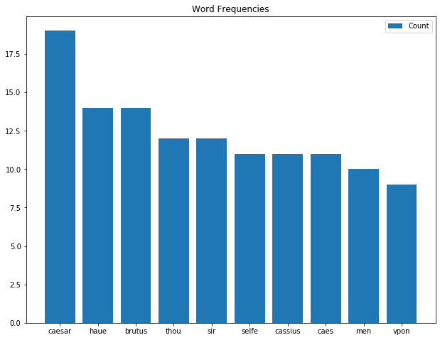

```python
import matplotlib.pyplot as plt
fig = plt.figure(figsize=(8,6))
ax = fig.add_axes([0,0,1,1])


words = [word for word,_ in common_words]
counts = [count for _,count in common_words]

ax.bar(words,counts,label='Count')
plt.title('Word Frequencies')
plt.legend()
plt.show()
```

**Observation:** The above plot illustrates the distribution of frequencies of most common words in a sample of text extracted from Julius Casear. We can see that the "caesar" is the most common word with 19 occurences. And "thou" is the fourth most common word.